# Algorithms: solving problems with computation

## Algorithms: solving problems with computation

### Ideas that shape what programs—and science—can do

Stanislav (Stanley) Modrak  
Draft MQB adaptation for contributor review

After Robert Sedgewick and Kevin Wayne, *Algorithms*, 4th edition  
[Section 1.4: Analysis of Algorithms](https://algs4.cs.princeton.edu/14analysis/)

## The question

Suppose we have a scientific problem and a program that appears to solve it.

**Is this a good way to solve the problem—and what might a better algorithm make possible?**

We will consider:

1. correctness, assumptions and clarity;
2. data structures and alternative procedures;
3. measurements and models of how work grows; and
4. the scientific and wider consequences of algorithmic choices.

## Where this fits in the MQB workflow

**Plan → implement → test → profile → analyse → improve → explain → rerun**

- Testing asks whether observed behaviour agrees with an independently expected result.
- Profiling asks where a particular run spent its time.
- Algorithm analysis asks how the required work changes with input size.

**Correctness comes first.** A fast wrong answer is still wrong—just sooner.

## Why study algorithms?

- **To solve problems that could not otherwise be addressed.** A different formulation can remove enormous amounts of unnecessary work.
- **To become a proficient programmer.** Syntax helps us express a solution; algorithms help us decide whether it is a sensible solution.
- **For intellectual stimulation.** Some people relax with crosswords. Others try to remove a factor of $n$. We shall not judge either group.

## Algorithms go rather a long way

- **Their impact is broad and far-reaching:** science, transport, medicine, communication, finance and everyday life online.
- **They may unlock the secrets of life—and perhaps the universe.** It seems polite to give both a well-specified algorithm and a proper test.
- **For profit.** Search, routing, recommendation and trading algorithms have done rather well. Profit is not, however, evidence of scientific validity or social virtue.

[figure not shown]

A montage from the original lecture showing algorithms in public discussion.

## Two ideas we need

**Algorithm:** a precise sequence of steps for solving a specified problem.

**Data structure:** a way of organising data so that useful operations can be carried out.

The same problem may have several correct algorithms. Their choice of data structure can change how much work they require.

## A long history, not a new fashion

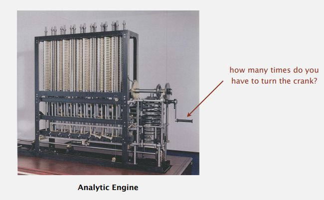

Charles Babbage’s Analytical Engine from the original lecture.

Long before electronic computers, people were already asking:

- Which operations must be performed?
- How many times must each operation be repeated?
- Can the procedure be reorganised?

## Algorithms can change what science is feasible

- Genome assembly became tractable through graph-based representations and algorithms that avoid comparing every possible reconstruction.
- Ecological null models and simulations can often reuse quantities that have not changed instead of recalculating the entire state.

The important claim is not one universal complexity for either field. It is that **reformulating the computation can remove enormous amounts of repeated work**.

## Develop the evidence in the right order

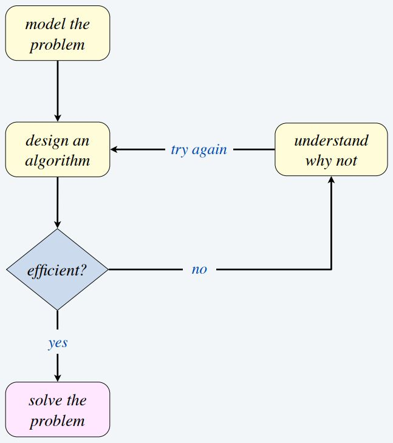

**Problem → algorithm → implementation → measurement → model**

## Worked example: 3-SUM

Given a collection of **distinct integers**, how many triples sum to exactly zero?

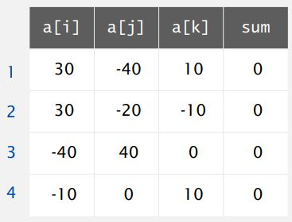

Four triples summing to zero in the eight-value example from the original lecture.

For `30, -40, -20, -10, 40, 0, 10, 5`, the expected answer is **4**.

## A transparent brute-force algorithm

```python
def count_three_sum(values: list[int]) -> int:
    """Count index triples whose values sum to zero."""
    n = len(values)
    count = 0
    for i in range(n):
        for j in range(i + 1, n):
            for k in range(j + 1, n):
                if values[i] + values[j] + values[k] == 0:
                    count += 1
    return count
```

**Before timing it:** which test would persuade you that it counts the intended triples?

## What does input size mean here?

Let $n$ be the number of integers.

The running time is a function $T(n)$, but it can also depend on:

- the actual values in the input;
- the Python implementation and libraries;
- the processor, memory and cache;
- the operating system and other work on the machine.

So how can we measure it sensibly?

## When should we optimise?

> “Premature optimization is the root of all evil.”

> — Donald Knuth, [*Structured Programming with go to Statements*](https://doi.org/10.1145/356635.356640), 1974

**What does this warning *not* mean?**

## Measure before you model

```python
from statistics import median
from time import perf_counter

def elapsed_seconds(function, argument, repetitions=5):
    function(argument)  # untimed warm-up
    times = []
    for _ in range(repetitions):
        start = perf_counter()
        function(argument)
        times.append(perf_counter() - start)
    return median(times)
```

- Use several input sizes.
- Repeat timings and report the median.
- Time equivalent work and record the environment.
- Check the result as well as the clock.

## What pattern do the measurements suggest?

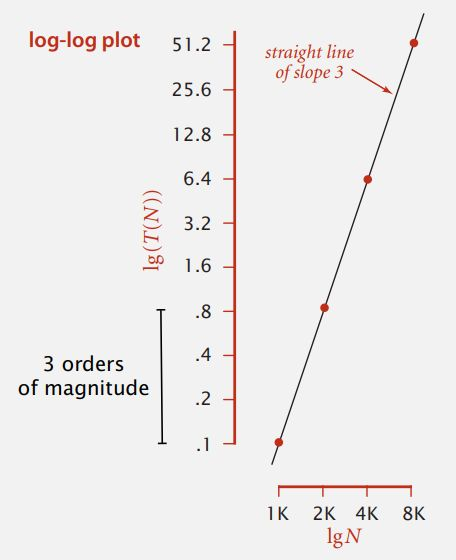

Original log-log timing plot for the brute-force 3-SUM example.

If multiplying $n$ by 2 multiplies time by about 8, that is evidence consistent with cubic growth because $2^3 = 8$.

## A useful empirical model

The slope $b$ describes the observed scaling over the measured range. The coefficient $a$ absorbs machine- and implementation-dependent costs.

## Faster hardware changes the coefficient—not the question

[figure not shown]

A historical computer and a modern laptop linked by a large speed increase.

A faster computer may reduce every measured time. It does not usually change the number of triples examined by this algorithm.

**How long until growth in the input consumes the hardware gain?**

## From timings to a mathematical model

Exact costs are awkward and machine-dependent. Instead:

1. choose an operation that captures the main repeated work; and
2. count how often the algorithm performs it as $n$ grows.

## A simple cost model: 1-SUM

```python
def count_zeros(values: list[int]) -> int:
    count = 0
    for value in values:
        if value == 0:
            count += 1
    return count
```

If comparison with zero is the chosen operation, how many comparisons occur for a list of length $n$?

**Exactly $n$**—whether the list contains no zeroes or many.

## Keep the part that governs growth

This discards the leading coefficient and lower-order terms—not because they never matter, but because the model is asking how the work scales.

## Big Theta and Big O are not interchangeable

- $\Theta(g(n))$: a **tight** asymptotic growth class—both an upper and lower bound.
- $O(g(n))$: an asymptotic **upper bound**.

If an algorithm takes $\Theta(n)$ work, it is also $O(n^2)$, but $O(n^2)$ does not describe it tightly.

In informal conversation people often say “Big O” when they mean order of growth. Here we will use $\Theta$ when claiming a tight class.

## Common orders of growth

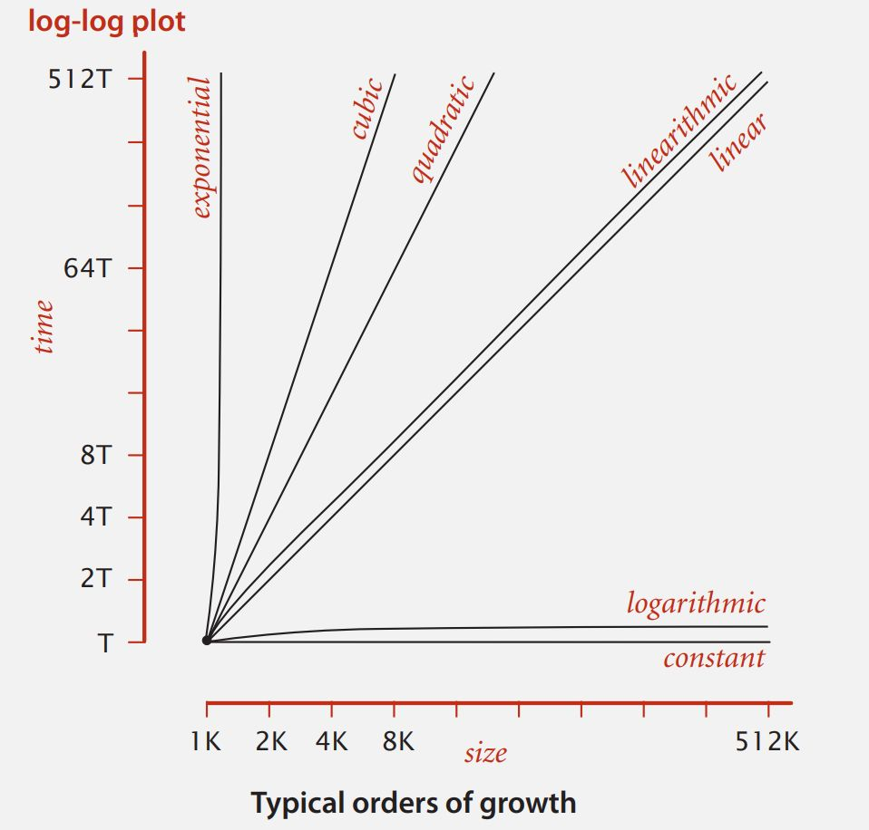

Curves for constant, logarithmic, linear, linearithmic, quadratic, cubic and exponential growth from the original lecture.

## What happens when the input doubles?

| Growth | Approximate multiplier when $n\rightarrow2n$ |
| --- | --- |
| $1$ | 1 |
| $\log n$ | slightly more than 1 |
| $n$ | 2 |
| $n\log n$ | a little more than 2 |
| $n^2$ | 4 |
| $n^3$ | 8 |
| $2^n$ | squares its previous value |

**Predict first:** which pattern should the triple loop show?

## Break

When we return: can a different data structure turn a quadratic algorithm into a linear one?

## Worked comparison: 2-SUM

Given a collection of **distinct integers**, count the pairs whose sum is zero.

Before seeing code:

- What result do you expect for `[3, -3, 5, 8, -8]`?
- What should happen for an empty list?
- Why does “distinct integers” matter?

## Approach 1: compare every pair

```python
def count_two_sum_brute(values: list[int]) -> int:
    count = 0
    n = len(values)
    for i in range(n):
        for j in range(i + 1, n):
            if values[i] + values[j] == 0:
                count += 1
    return count
```

so the running time is $\Theta(n^2)$.

## Approach 2: remember what we have seen

```python
def count_two_sum_set(values: list[int]) -> int:
    seen: set[int] = set()
    count = 0
    for value in values:
        if -value in seen:
            count += 1
        seen.add(value)
    return count
```

With average constant-time set lookup and insertion:

- expected running time: $\Theta(n)$;
- additional memory: $\Theta(n)$.

## Same answer? Check before celebrating

```python
examples = [
    ([], 0),
    ([4], 0),
    ([3, -3, 5, 8, -8], 2),
    ([-10, -2, 0, 6, 10], 1),
]

for values, expected in examples:
    assert count_two_sum_brute(values) == expected
    assert count_two_sum_set(values) == expected
```

These checks support the stated **distinct-integer** problem. They do not show that the set version counts every index pair correctly when values repeat.

## Practical: predict, test and explain scaling

In pairs:

1. Copy the two 2-SUM functions into a fresh script.
2. Add the shared correctness checks.
3. Predict the growth class of each implementation and the effect of doubling $n$.
4. Generate distinct inputs of several sizes with known or independently checked answers.
5. After one warm-up, record the median of at least five timings for each size.
6. Decide whether the evidence agrees with your prediction.

Record the environment and time only the pair-counting function—not input generation, printing or plotting.

## Practical debrief

Be ready to explain:

- whether both functions passed the same checks;
- how elapsed time changed when $n$ doubled;
- why the set changes the amount of repeated work;
- what extra memory the faster algorithm uses; and
- one limitation of your measurement.

## Memory is part of performance

Ask how the largest amount of memory held at one time grows with $n$.

- The brute-force 2-SUM loop uses little additional memory: $\Theta(1)$.
- The set-based algorithm stores up to $n$ values: $\Theta(n)$.

The faster algorithm is not free. It exchanges memory for fewer comparisons.

## Improve the algorithm before buying hardware

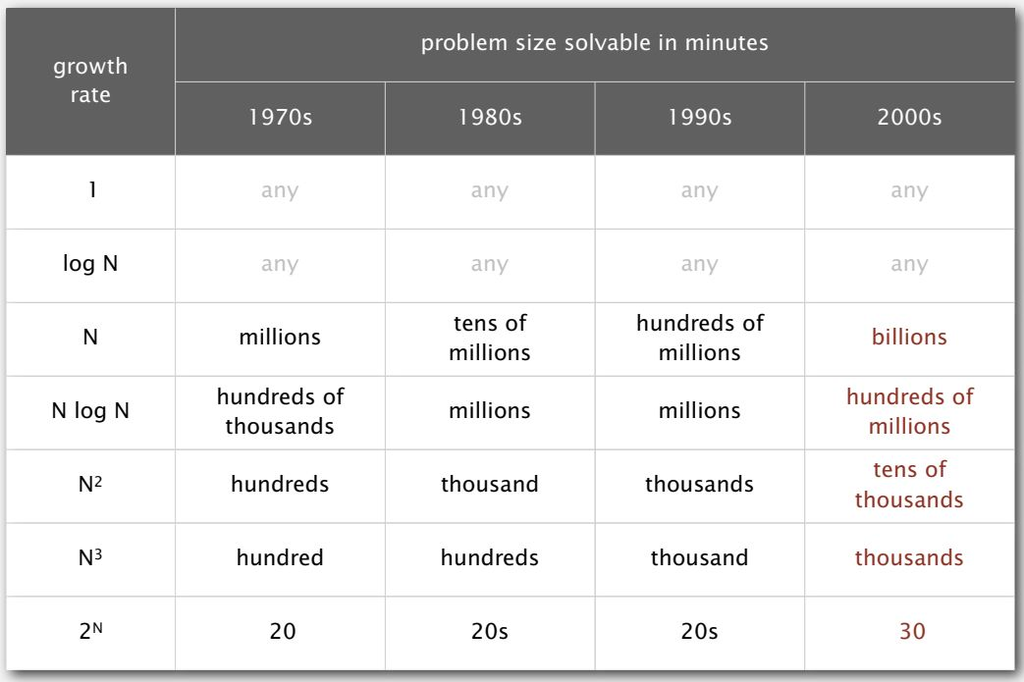

Original illustration of the orders of growth that remain practical as problem size increases.

A change from $\Theta(n^2)$ to expected $\Theta(n)$ can save orders of magnitude. Adding processors usually changes performance by a bounded factor.

## Parallelism and HPC: the next layer

**Parallelism** performs independent operations at the same time.

**High-performance computing (HPC)** provides larger or specialised resources—such as many CPU cores, GPUs or high-memory nodes—for suitable workloads.

- Independent simulations or parameter combinations may parallelise well.
- Steps that depend on previous results remain sequential.
- Coordination and data movement also cost time.

**Choose a suitable algorithm first; then ask whether parallel hardware helps.**

## What should you now be able to do?

Given two implementations of the same problem, you should be able to:

1. explain why the algorithmic choice matters;
2. state the input, output and assumptions;
3. check that both produce the intended result;
4. measure comparable runs over several input sizes;
5. predict and explain their orders of growth;
6. identify a time-memory trade-off; and
7. justify which implementation you would use.

## From an algorithm to evidence

A clean notebook can present:

- the problem and assumptions;
- the shared correctness checks;
- the timing method and results;
- the predicted and observed scaling; and
- your reason for accepting or rejecting any suggested improvement.

The notebook explains the evidence. The reusable functions still belong in a script that can be tested independently.

## Sources and review status

This draft adapts:

> Stanislav (Stanley) Modrak, *Analysis of algorithms*, adapted from Robert Sedgewick and Kevin Wayne, *Algorithms*, 4th edition (Addison-Wesley, 2011), especially [Section 1.4: Analysis of Algorithms](https://algs4.cs.princeton.edu/14analysis/) and its [Princeton lecture slides](https://algs4.cs.princeton.edu/lectures/keynote/14AnalysisOfAlgorithms.pdf).

The MQB redraft retains the broad motivations while adding explicit correctness checks, repeated timing and clearer time-memory trade-offs.

**Before release:** review the visual provenance, permissions and teaching fit.